```python
# Import all the necessary libraries to perform analysis

import numpy as np
import pandas as pd
import matplotlib.pyplot as plt
%matplotlib inline
from math import *
```

```python
# Loading the stroop dataset

df_stroop = pd.read_csv('stroopdata.csv')

# Going through the sample of data from the dataset

df_stroop.head()
```

|  | Congruent | Incongruent |
| --- | --- | --- |
| 0 | 12.079 | 19.278 |
| 1 | 16.791 | 18.741 |
| 2 | 9.564 | 21.214 |
| 3 | 8.630 | 15.687 |
| 4 | 14.669 | 22.803 |

# 1. Identify variables in the experiment?

INDEPENDANT - Words condition whether they are congruent or incongruent

DEPENDANT - Response time

# 2. What is an appropriate set of hypotheses for this task? What kind of statistical test do you expect to perform? Justify your choices.

Ho - Null Hypothesis: ( μinc - μc = 0 ) No significant difference in the population average response time in

viewing both type of words. i.e., incongruent - (inc) and congruent - (c)

H1 - Alternative Hypothesis: ( μinc - μc ≠ 0 ) There is a significant difference in the population average response time

in viewing both type of words.

# 3. Report some descriptive statistics regarding this dataset. Include at least one measure of central tendency and at least one measure of variability.

```python
# Data frames that contains only one type of variable data

inc = df_stroop['Incongruent']

c = df_stroop['Congruent']
```

```python
# Calculating the mean of response time of both type of word data

inc_mean = inc.mean()

print(inc_mean)

c_mean = c.mean()

print(c_mean)
```

```
22.01591666666667
14.051125000000004
```

```python
# Calculating the standard deviations of both type of word data

inc_std = inc.std()

print(inc_std)

c_std = c.std()

print(c_std)
```

```
4.797057122469138
3.559357957645195
```

# 4. Provide one or two visualizations that show the distribution of the sample data. Write one or two sentences noting what you observe about the plot or plots.

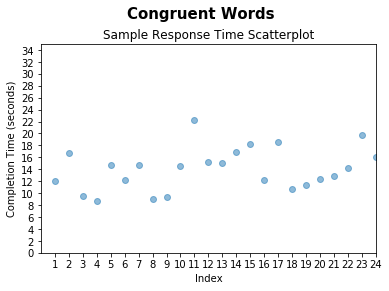

```python
x = df_stroop.index + 1

y = df_stroop['Congruent']

fig = plt.figure()

fig.suptitle('Congruent Words ', fontsize=15, fontweight='bold')

ax = fig.add_subplot(111)

fig.subplots_adjust(top=0.85)

ax.set_title('Sample Response Time Scatterplot')

ax.set_xlabel('Index')

ax.set_ylabel('Completion Time (seconds)')

plt.xticks(np.arange(min(x), max(x)+1, 1.0))

plt.yticks(np.arange(0, 35, 2))

plt.scatter(x, y, alpha=0.5)

plt.ylim([0,35])

plt.xlim([0,24])

plt.show()
```

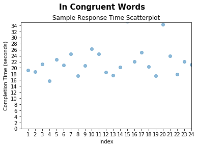

```python
N = len(df_stroop)

x = df_stroop.index + 1

y = df_stroop['Incongruent']

fig = plt.figure()

fig.suptitle('In Congruent Words ', fontsize=15, fontweight='bold')

ax = fig.add_subplot(111)

fig.subplots_adjust(top=0.85)

ax.set_title('Sample Response Time Scatterplot')

ax.set_xlabel('Index')

ax.set_ylabel('Completion Time (seconds)')

plt.xticks(np.arange(min(x), max(x)+1, 1.0))

plt.yticks(np.arange(0, 35, 2))

plt.scatter(x, y, alpha=0.5)

plt.ylim([0,35])

plt.xlim([0,24])

plt.show()
```

above, we can definitely state that the average response time of In congruent words is higher than the Congruent

words.

# 5. Now, perform the statistical test and report your results. What is your confidence level and your critical statistic value? Do you reject the null hypothesis or fail to reject it? Come to a conclusion in terms of the experiment task. Did the results match up with your expectations?¶

Confidence Level = 90%

t_critical value (2-sided test) -> from t-table

```python
# Number of records in the sample

number = len(df_stroop)

print(number)
```

```
24
```

```python
# Point Estimate of μinc - μc -> PE (in seconds)

PE = inc_mean - c_mean

print(PE)
```

```
7.964791666666665
```

```python
# s - Sample Standard Deviation of differences

# 1. diff = Sample Difference

df_stroop['diff'] = df_stroop['Incongruent'] - df_stroop['Congruent']

# 2. D_F_M = Difference from the Mean

# S_Q_D = Squared Differences from the Mean

D_F_M = df_stroop['diff'] - df_stroop['diff'].mean()

df_stroop['S_Q_D'] = D_F_M*D_F_M

# 3. S_S_D = Sum of Squared Differences

S_S_D = df_stroop['S_Q_D'].sum()

# 4. V = Variance = S_S_D/(number-1)

V = S_S_D/(number-1)

# 5. S = sqrt(V)

S = sqrt(V)

print(S)
```

```
4.864826910359056
```

```python
# t-statistic

# T = PE/(S/√number)

# PE = (μinc - μc)

T = PE/(S/(sqrt(number)))

print(T)
```

```
8.020706944109955
```

t-statistic > t-critical

8.0207 > 1.711

# Conclusion:

We reject the Null Hypothesis which states that there is no significant differences between the population average

completion time for the two different conditions (Congruent & Incongruent). In theory, if we were able to calculate

the average difference of every single person person who took this pair of tests (the population) we expect there

would be a significantly slower or significantly faster time in either the the incongruent or congruent condition.

# References

1. https://s3.amazonaws.com/udacity-hosted-downloads/t-table.jpg
2. https://en.wikipedia.org/wiki/Stroop_effect
3. http://www.statisticshowto.com/when-to-use-a-t-score-vs-z-score/